# 03 Filter HUCs

### Raw catchment datasets

The starting datasets include

1. Maavara et al.’s MERIT catchment dataset
2. my downloaded MERIT catchment dataset, and
3. my downloaded MERIT flowline dataset.

My MERIT catchment and flowline datasets have been cropped to CONUS’s spatial extent by `02_crop_merit_to_conus.R`.

| dataset | rows | unique_comids |
| --- | --- | --- |
| MERIT catchments | 172591 | 172591 |
| MERIT flowlines | 172852 | 172852 |
| Maavara catchments | 175116 | 175116 |

This table confirms that all rows contain unique COMIDs - a good check before any filtering starts.

### Decision #1: Which catchments match well enough to keep?

Because flowlines are not provided with Maavara et al.’s dataset, we need to download flowlines. To make sure we’re matching the MERIT dataset provided by Maavara et al., we first need to check if catchments provided by Maavara spatially match catchments.

```
## 95.807 sec elapsed
```

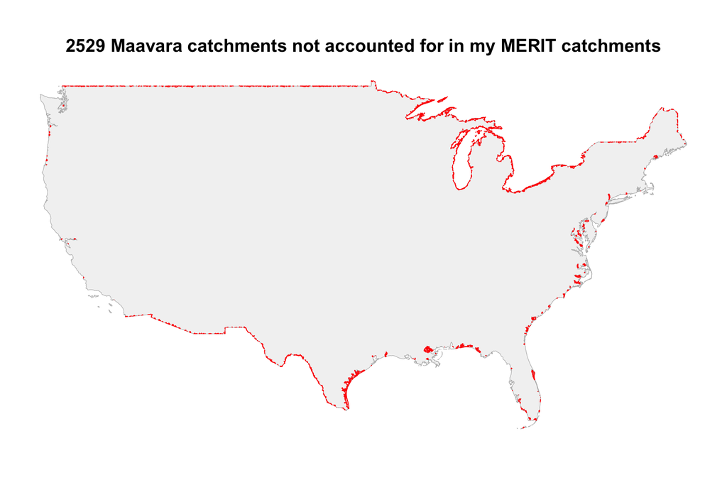

Now let’s compare how close centroids are between the two MERIT datasets

Not very many catchments have a large centroid distance

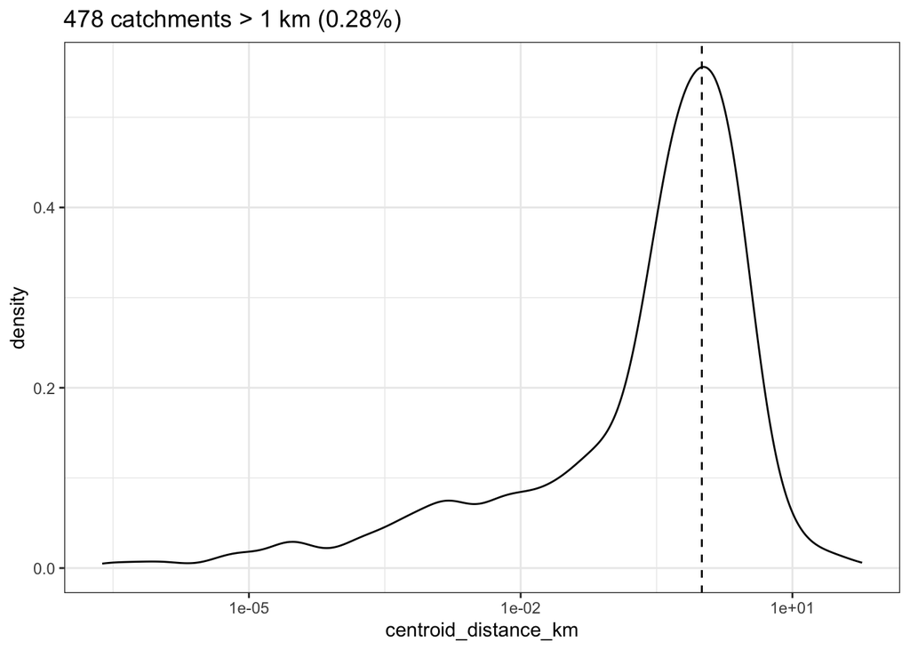

Based on the data above, we set this threshold as a filtering decision

- `centroid_threshold_km <- 1`: We treat Maavara and MERIT catchments with centroids more than 1 km apart as mismatched, because this is a conservative spatial-identity filter meant to remove COMIDs where shared IDs may not represent the same landscape unit. Below are the catchments we’ll remove from the pipeline at this point.

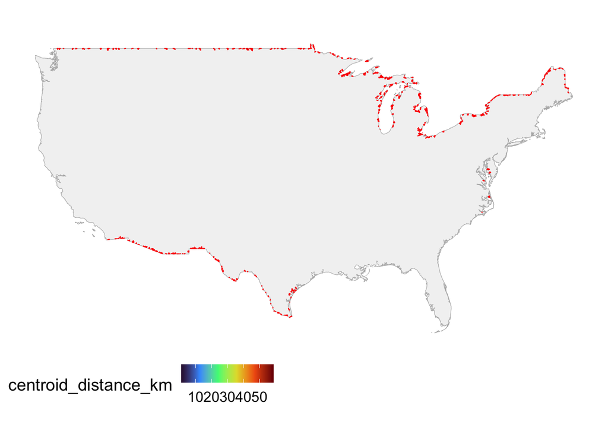

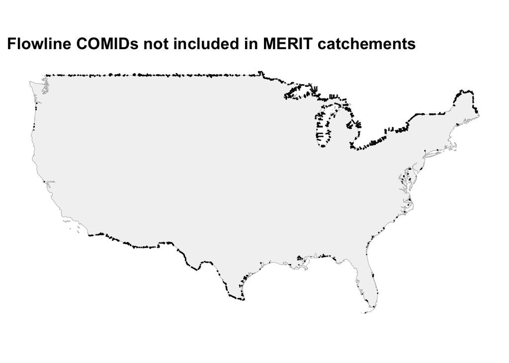

### Decision #2: We should only include HUCs with sufficent spatial coverage

```
## read in HUCs: 204.88 sec elapsed
```

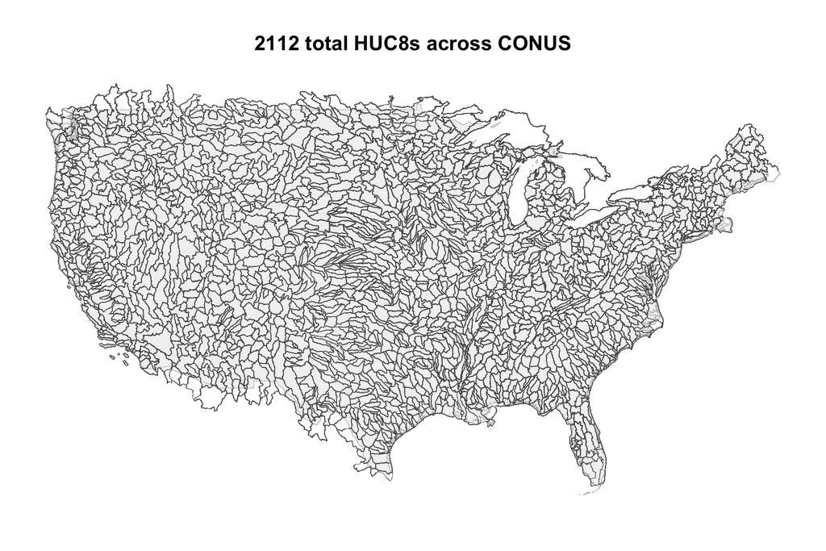

[output not shown]

[output not shown]

[output not shown]

[output not shown]

[output not shown]

[output not shown]

[output not shown]

[output not shown]

[output not shown]

[output not shown]

[output not shown]

[output not shown]

[output not shown]

[output not shown]

[output not shown]

[output not shown]

[output not shown]

[output not shown]

[output not shown]

[output not shown]

[output not shown]

[output not shown]

[output not shown]

[output not shown]

[output not shown]

[output not shown]

[output not shown]

[output not shown]

[output not shown]

[output not shown]

[output not shown]

[output not shown]

[output not shown]

[output not shown]

[output not shown]

[output not shown]

[output not shown]

[output not shown]

[output not shown]

[output not shown]

[output not shown]

[output not shown]

[output not shown]

- `min_coverage <- 75%`: We require at least 75% of the area within a HUC8 to be covered by catchments that match Maavara (see Decision #1 above), because poor coverage could lead to biased catchment calculations or spatial gaps, which could break allometry assumptions.

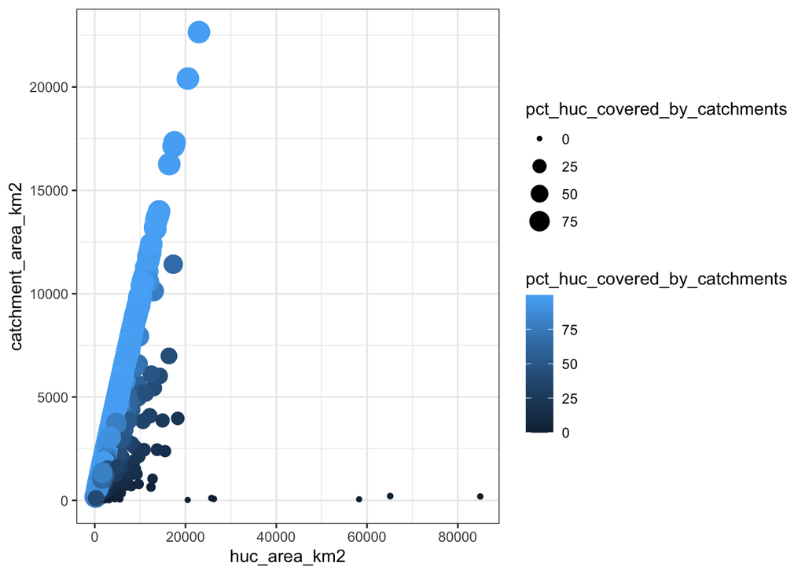

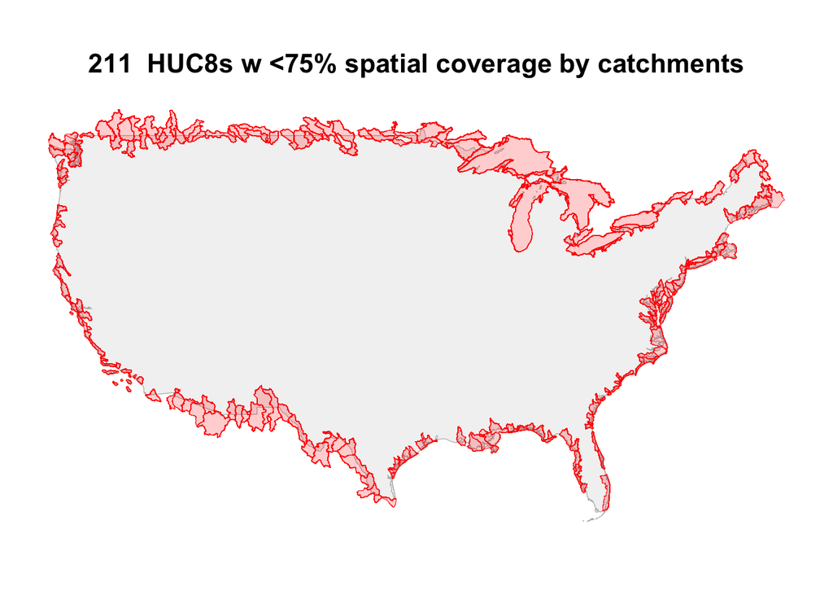

### Decision 3 - remove HUCs with too few flowlines

```
## # A tibble: 7 × 2
##   huc      n_flowliness
##   <chr>           <int>
## 1 04140203            8
## 2 05030104            5
## 3 08010206            8
## 4 08040305            6
## 5 17110016            5
## 6 17110017            7
## 7 18070204            7
```

### Decision 4 - we shouldn’t use metabolism data for non-approved catchments / flowlines

```
## # A tibble: 2 × 4
##   cleaning_step data                             n_gpp    n_er
##           <dbl> <chr>                            <int>   <int>
## 1             0 all metabolism data            2101332 2101332
## 2             1 matched to approved catchments 1968852 1968852
```

```
## [1] "This script took 15.9 minutes to run"
```